# Case Study: How Can a Wellness Technology Company Play It Smart?

Favre Emma

2025-08-21

### Context

Bellabeat is a small tech company founded in 2013 that makes health products for women. Their devices track activity, sleep, stress, and reproductive health. The company aims to grow in the smart device market.

Urška Sršen, cofounder and Chief Creative Officer, believes that studying how people use smart devices can help Bellabeat expand. She asked the marketing analytics team to analyze usage data from Bellabeat’s products to understand usage patterns and provide recommendations for marketing improvements.

#### Business Goal

The task is to identify potential opportunities for growth and recommend ways to improve Bellabeat’s marketing strategy based on trends in smart device usage.

**Key questions include:** - How do people use their smart devices and what patterns emerge? - How can these trends be applied to Bellabeat customers? - What opportunities exist to attract more users or increase engagement?

#### Stakeholders

- **Urška Sršen** – Bellabeat cofounder and Chief Creative Officer, interested in strategic growth insights.
- **Sando Mur** – Bellabeat cofounder and key executive team member.
- **Bellabeat Marketing Analytics Team** – Responsible for analyzing usage data and providing actionable recommendations.

#### About the Data

For this analysis, I used publicly available data on daily habits of smart device users, downloaded as a zip file from Kaggle. The zip contains two folders, each covering different time periods:

- **Folder 1:** 11 CSV files, including daily activity, heart rate, hourly calories, and other metrics.
- **Folder 2:** 18 CSV files, which include all files from Folder 1 plus additional data, such as daily calories, daily steps, and more detailed sleep information.

These datasets were made available through Mobius on Kaggle and licensed under the CCO Public Domain. According to the dataset information available on Zenodo.org, the data were generated by respondents to a distributed survey via Amazon Mechanical Turk between March 12 and May 12, 2016.

### Data Preparation

What I noticed about the datasets:

- **Folder 1:** Lacks detailed daily data for some metrics (e.g., no daily calories, daily steps, or “Wide” minute-level files).
- **Folder 2:** Contains more detailed data, including:
  - Daily data for calories, steps, and activity intensity.
  - “Wide” versions of minute-level data with additional columns.
  - Sleep data in both daily and minute formats.

To simplify the analysis and reduce data cleaning, I focused on the most complete month, from **April to May 2016**.

Next, due to the small sample size, I will use spreadsheets to explore the different tables in this folder and get an overview of their structure by filtering and sorting them.

Here are the different tables with a description :

[output not shown]

##### Observations

- The data is in long format.
- Each user is identified by a unique ID, with several rows corresponding to recording dates and times.
- In my opinion, the *Wide* format files are less relevant for analysis than the *Narrow* format ones.
- Some files (`heartrate_seconds_merged`, `minuteMETsNarrow_merged`, `minuteStepsNarrow_merged`) are very large and difficult to work with in a spreadsheet.
- The `dailyActivity` file contains exactly the same information as the `dailyCalories`, `dailyIntensities`, and `dailySteps` files.

##### Limitations

For my analysis, I will focus mainly on the dailyActivity file, while also considering the sleepDay file, which is less complete but may offer useful insights into sleep patterns.

I will use R for the remainder of my work. Before cleaning the data, I performed several preparing steps in R.

**A. Setting up the working environment**

Defined the working directory using setwd() and verified it with getwd(). Loaded essential libraries: tidyverse for data manipulation, skimr for quick summaries, and janitor for cleaning column names.

**B. Loading the datasets**

I imported the dailyActivity_merged.csv and sleepDay_merged.csv files using read.csv(), then checked the structure of each dataset with str() and viewed the first few rows using head().

#### Data Dictionaries

Here are the data dictionaries for the `dailyActivity` and `sleepDay` files to better understand their components.

Data dictionary of the dailyActivity dataset

| Column.Name | Description | Type |
| --- | --- | --- |
| Id | User ID | numeric |
| ActivityDate | Date of activity | factor |
| TotalSteps | Total steps | integer |
| TotalDistance | Total distance (km) | numeric |
| TrackerDistance | Distance tracked by device (km) | numeric |
| LoggedActivitiesDistance | Distance from logged activities (km) | numeric |
| VeryActiveDistance | Very active distance (km) | numeric |
| ModeratelyActiveDistance | Moderately active distance (km) | numeric |
| LightActiveDistance | Light active distance (km) | numeric |
| SedentaryActiveDistance | Sedentary distance (km) | numeric |
| VeryActiveMinutes | Very active minutes | integer |
| FairlyActiveMinutes | Fairly active minutes | integer |
| LightlyActiveMinutes | Lightly active minutes | integer |
| SedentaryMinutes | Sedentary minutes | integer |
| Calories | Calories burned | integer |

Data dictionary of the dailySleep dataset

| Column.Name | Description | Type |
| --- | --- | --- |
| Id | User ID | numeric |
| SleepDay | Date of sleep | factor |
| TotalSleepRecords | Number of sleep records | integer |
| TotalMinutesAsleep | Total minutes asleep | integer |
| TotalTimeInBed | Total time in bed (minutes) | integer |

We observe that dailyActivity contains many details on physical activity (various types of distances and active minutes), while dailySleep focuses only on sleep and time in bed. Both datasets include an Id column to identify users and a date column, allowing for the possibility of merging the data. Most numeric columns (steps, distances, minutes, calories) are correctly stored as numeric or integer. The date columns are factors, which is not ideal for temporal analysis.

C. Summarization of the key statistics for important columns like TotalSteps, TotalDistance, SedentaryMinutes for activity, and TotalSleepRecords, TotalMinutesAsleep, TotalTimeInBed for sleep.

```r
library(tidyverse)

daily_activity <- read.csv("dailyActivity_merged.csv", header=TRUE, sep=",", dec=".",stringsAsFactors = TRUE)
daily_sleep <- read.csv("sleepDay_merged.csv", header=TRUE, sep=",", dec=".",stringsAsFactors = TRUE)

# Résumé pour daily_activity
daily_activity %>%
  select(TotalSteps, TotalDistance, SedentaryMinutes) %>%
  summary()
```

```
##    TotalSteps    TotalDistance    SedentaryMinutes
##  Min.   :    0   Min.   : 0.000   Min.   :   0.0
##  1st Qu.: 3790   1st Qu.: 2.620   1st Qu.: 729.8
##  Median : 7406   Median : 5.245   Median :1057.5
##  Mean   : 7638   Mean   : 5.490   Mean   : 991.2
##  3rd Qu.:10727   3rd Qu.: 7.713   3rd Qu.:1229.5
##  Max.   :36019   Max.   :28.030   Max.   :1440.0
```

```r
# Résumé pour daily_sleep
daily_sleep %>%
  select(TotalSleepRecords, TotalMinutesAsleep, TotalTimeInBed) %>%
  summary()
```

```
##  TotalSleepRecords TotalMinutesAsleep TotalTimeInBed
##  Min.   :1.000     Min.   : 58.0      Min.   : 61.0
##  1st Qu.:1.000     1st Qu.:361.0      1st Qu.:403.0
##  Median :1.000     Median :433.0      Median :463.0
##  Mean   :1.119     Mean   :419.5      Mean   :458.6
##  3rd Qu.:1.000     3rd Qu.:490.0      3rd Qu.:526.0
##  Max.   :3.000     Max.   :796.0      Max.   :961.0
```

### Cleaning

Let’s now proceed with data cleaning.

```r
library(dplyr)
library(janitor)

# 1. Check that the IDs are unique
n_distinct(daily_activity$Id)
```

```
## [1] 33
```

```r
n_distinct(daily_sleep$Id)
```

```
## [1] 24
```

```r
# 2. Check for duplicates & NA's
sum(duplicated(daily_activity))
```

```
## [1] 0
```

```r
sum(is.na(daily_activity))
```

```
## [1] 0
```

```r
sum(duplicated(daily_sleep))
```

```
## [1] 3
```

```r
sum(is.na(daily_sleep))
```

```
## [1] 0
```

```r
# 3. Remove for duplicates and NA's
daily_activity <- daily_activity %>%
  distinct() %>%
  drop_na()

daily_sleep <- daily_sleep %>%
  distinct() %>%
  drop_na()

# Verification
sum(duplicated(daily_sleep))
```

```
## [1] 0
```

```r
#4. Now we will use the janitor package to clean the column names (remove spaces, special characters, accents, and make the names consistent & min)
clean_names(daily_activity)
daily_activity<- rename_with(daily_activity,tolower)

clean_names(daily_sleep)
daily_sleep <- rename_with(daily_sleep,tolower)

# 5. Cleaning date-time format
daily_activity <- daily_activity %>%
  rename(date = activitydate) %>%
  mutate(date = as.Date(date, format = "%m/%d/%Y"))

daily_sleep <- daily_sleep %>%
  rename(date = sleepday) %>%
  mutate(date = as.Date(date,format ="%m/%d/%Y %I:%M:%S %p" , tz=Sys.timezone()))
```

```r
# Verification
head(daily_activity)
```

```
##           id       date totalsteps totaldistance trackerdistance
## 1 1503960366 2016-04-12      13162          8.50            8.50
## 2 1503960366 2016-04-13      10735          6.97            6.97
## 3 1503960366 2016-04-14      10460          6.74            6.74
## 4 1503960366 2016-04-15       9762          6.28            6.28
## 5 1503960366 2016-04-16      12669          8.16            8.16
## 6 1503960366 2016-04-17       9705          6.48            6.48
##   loggedactivitiesdistance veryactivedistance moderatelyactivedistance
## 1                        0               1.88                     0.55
## 2                        0               1.57                     0.69
## 3                        0               2.44                     0.40
## 4                        0               2.14                     1.26
## 5                        0               2.71                     0.41
## 6                        0               3.19                     0.78
##   lightactivedistance sedentaryactivedistance veryactiveminutes
## 1                6.06                       0                25
## 2                4.71                       0                21
## 3                3.91                       0                30
## 4                2.83                       0                29
## 5                5.04                       0                36
## 6                2.51                       0                38
##   fairlyactiveminutes lightlyactiveminutes sedentaryminutes calories
## 1                  13                  328              728     1985
## 2                  19                  217              776     1797
## 3                  11                  181             1218     1776
## 4                  34                  209              726     1745
## 5                  10                  221              773     1863
## 6                  20                  164              539     1728
```

```r
head(daily_sleep)
```

```
##           id       date totalsleeprecords totalminutesasleep totaltimeinbed
## 1 1503960366 2016-04-12                 1                327            346
## 2 1503960366 2016-04-13                 2                384            407
## 3 1503960366 2016-04-15                 1                412            442
## 4 1503960366 2016-04-16                 2                340            367
## 5 1503960366 2016-04-17                 1                700            712
## 6 1503960366 2016-04-19                 1                304            320
```

```r
# 6. Merging the two datasets
daily_activity_sleep <- merge(daily_activity, daily_sleep, by=c("id", "date"))

# Aperçu final
glimpse(daily_activity_sleep)
```

```
## Rows: 410
## Columns: 18
## $ id                       <dbl> 1503960366, 1503960366, 1503960366, 150396036…
## $ date                     <date> 2016-04-12, 2016-04-13, 2016-04-15, 2016-04-…
## $ totalsteps               <int> 13162, 10735, 9762, 12669, 9705, 15506, 10544…
## $ totaldistance            <dbl> 8.50, 6.97, 6.28, 8.16, 6.48, 9.88, 6.68, 6.3…
## $ trackerdistance          <dbl> 8.50, 6.97, 6.28, 8.16, 6.48, 9.88, 6.68, 6.3…
## $ loggedactivitiesdistance <dbl> 0, 0, 0, 0, 0, 0, 0, 0, 0, 0, 0, 0, 0, 0, 0, …
## $ veryactivedistance       <dbl> 1.88, 1.57, 2.14, 2.71, 3.19, 3.53, 1.96, 1.3…
## $ moderatelyactivedistance <dbl> 0.55, 0.69, 1.26, 0.41, 0.78, 1.32, 0.48, 0.3…
## $ lightactivedistance      <dbl> 6.06, 4.71, 2.83, 5.04, 2.51, 5.03, 4.24, 4.6…
## $ sedentaryactivedistance  <dbl> 0, 0, 0, 0, 0, 0, 0, 0, 0, 0, 0, 0, 0, 0, 0, …
## $ veryactiveminutes        <int> 25, 21, 29, 36, 38, 50, 28, 19, 41, 39, 73, 3…
## $ fairlyactiveminutes      <int> 13, 19, 34, 10, 20, 31, 12, 8, 21, 5, 14, 23,…
## $ lightlyactiveminutes     <int> 328, 217, 209, 221, 164, 264, 205, 211, 262, …
## $ sedentaryminutes         <int> 728, 776, 726, 773, 539, 775, 818, 838, 732, …
## $ calories                 <int> 1985, 1797, 1745, 1863, 1728, 2035, 1786, 177…
## $ totalsleeprecords        <int> 1, 2, 1, 2, 1, 1, 1, 1, 1, 1, 1, 1, 1, 1, 1, …
## $ totalminutesasleep       <int> 327, 384, 412, 340, 700, 304, 360, 325, 361, …
## $ totaltimeinbed           <int> 346, 407, 442, 367, 712, 320, 377, 364, 384, …
```

```r
n_distinct(daily_activity_sleep$id)
```

```
## [1] 24
```

Our final merged dataset will therefore focus on only 24 participants, as these are the most complete data available. We are now ready to analyze the data.

### Consumers

The goal of this section is to understand user trends and gain deeper insights into our customers. To begin, we will install all the packages needed for the analysis :

install.packages(“dplyr”) # Data manipulation

install.packages(“ggplot2”) # Visualization

install.packages(“patchwork”) # Combining plots

install.packages(“tidyr”) # Data tidying

install.packages(“scales”) # Formatting axes and labels

install.packages(“tibble”) # Data frames

install.packages(“RColorBrewer”) # Color palettes for plots

install.packages(“ggpubr”) # Publication-ready ggplot2 plots and statistical annotations

**Now, let’s classify our users.**

Given the limited information available, we will first group them by activity level, and then by sleep duration to assess whether they are getting enough rest.

##### Overall view of each user’s activity level.

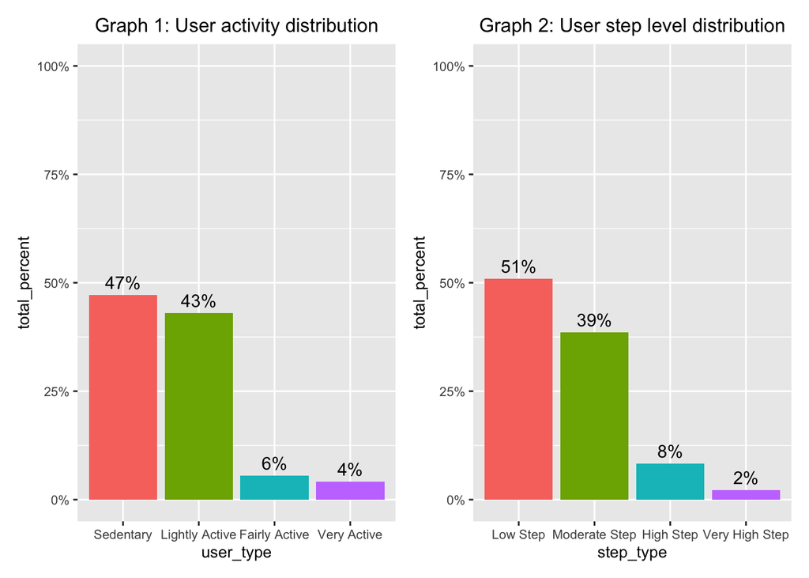

```r
library(patchwork)
user_activity <- daily_activity_sleep %>%
  reframe(
    user_type = factor(case_when(
      sedentaryminutes > mean(sedentaryminutes) & lightlyactiveminutes < mean(lightlyactiveminutes) & fairlyactiveminutes < mean(fairlyactiveminutes) & veryactiveminutes < mean(veryactiveminutes) ~ "Sedentary",
      sedentaryminutes < mean(sedentaryminutes) & lightlyactiveminutes > mean(lightlyactiveminutes) & fairlyactiveminutes < mean(fairlyactiveminutes) & veryactiveminutes < mean(veryactiveminutes) ~ "Lightly Active",
      sedentaryminutes < mean(sedentaryminutes) & lightlyactiveminutes < mean(lightlyactiveminutes) & fairlyactiveminutes > mean(fairlyactiveminutes) & veryactiveminutes < mean(veryactiveminutes) ~ "Fairly Active",
      sedentaryminutes < mean(sedentaryminutes) & lightlyactiveminutes < mean(lightlyactiveminutes) & fairlyactiveminutes < mean(fairlyactiveminutes) & veryactiveminutes > mean(veryactiveminutes) ~ "Very Active"
    ), levels = c("Sedentary", "Lightly Active", "Fairly Active", "Very Active")),
    calories,
    .by = id
  ) %>%
  drop_na()

data_by_steps <- daily_activity_sleep %>%
  reframe(
    step_type = factor(case_when(
      totalsteps < mean(totalsteps) ~ "Low Step",
      totalsteps >= mean(totalsteps) & totalsteps < 1.5*mean(totalsteps) ~ "Moderate Step",
      totalsteps >= 1.5*mean(totalsteps) & totalsteps < 2*mean(totalsteps) ~ "High Step",
      totalsteps >= 2*mean(totalsteps) ~ "Very High Step"
    ), levels = c("Low Step", "Moderate Step", "High Step", "Very High Step")),
    .by = id
  ) %>%
  drop_na()

# Graphique 1 : degré d'activités
plot1 <- user_activity %>%
  group_by(user_type) %>%
  summarise(total = n()) %>%
  mutate(total_percent = total / sum(total)) %>%
  ggplot(aes(user_type, y = total_percent, fill = user_type)) +
  geom_col() +
  geom_text(aes(label = scales::percent(total_percent, accuracy = 1)),
            vjust = -0.5) + # au-dessus de la barre
  scale_y_continuous(labels = scales::percent, limits = c(0,1)) +
  theme(legend.position = "none", text = element_text(size = 10),
        plot.title = element_text(hjust = 0.5)) +
  labs(title = "Graph 1: User activity distribution")

# Graphique 2 : nombre de pas
plot2 <- data_by_steps %>%
  group_by(step_type) %>%
  summarise(total = n()) %>%
  mutate(total_percent = total / sum(total)) %>%
  ggplot(aes(step_type, y = total_percent, fill = step_type)) +
  geom_col() +
  geom_text(aes(label = scales::percent(total_percent, accuracy = 1)),
            vjust = -0.5) +
  scale_y_continuous(labels = scales::percent, limits = c(0,1)) +
  theme(legend.position = "none", text = element_text(size = 10),
        plot.title = element_text(hjust = 0.5)) +
  labs(title = "Graph 2: User step level distribution")

# Mettre les deux graphiques côte à côte
plot1 + plot2
```

##### Observations

These charts classify users by activity type and step count. One chart categorizes overall activity level (Sedentary, Lightly, Fairly, Very Active), while the other classifies users by daily steps (Low, Moderate, High, Very High). Together, they show patterns in user behavior and allow us to identify groups based on different activity metrics. While 47% are classified as sedentary, 51% take few steps, showing that low step count doesn’t always match overall activity. The charts highlight these complementary perspectives. Finally, we can also determine that based on users activity all kind of users wear smart-devices.

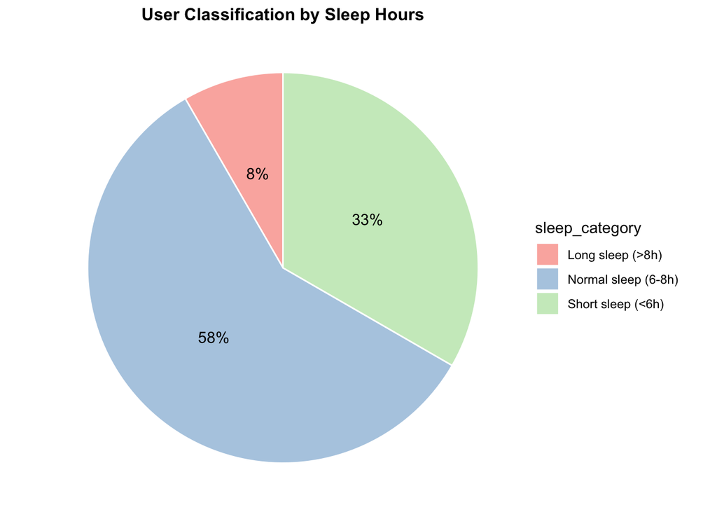

```r
library(dplyr)
library(ggplot2)

# Calculer la moyenne de sommeil par utilisateur
daily_activity_sleep_user <- daily_activity_sleep %>%
  group_by(id) %>%
  summarise(avg_sleep = mean(totalminutesasleep, na.rm = TRUE)) %>%
  ungroup() %>%
  # Créer la catégorie selon la moyenne
  mutate(sleep_category = case_when(
    avg_sleep < 360 ~ "Short sleep (<6h)",
    avg_sleep >= 360 & avg_sleep <= 480 ~ "Normal sleep (6-8h)",
    avg_sleep > 480 ~ "Long sleep (>8h)"
  ))

# Calculer la proportion par catégorie
sleep_summary <- daily_activity_sleep_user %>%
  group_by(sleep_category) %>%
  summarise(count = n()) %>%
  mutate(percent = count / sum(count))

# Camembert
ggplot(sleep_summary, aes(x = "", y = percent, fill = sleep_category)) +
  geom_col(width = 1, color = "white") +
  coord_polar(theta = "y") +
  geom_text(aes(label = scales::percent(percent, accuracy = 1)),
            position = position_stack(vjust = 0.5)) +
  labs(title = "User Classification by Sleep Hours") +
  theme_void() +
  theme(plot.title = element_text(hjust = 0.5, size = 12, face = "bold")) +
  scale_fill_brewer(palette = "Pastel1")
```

##### Observations

We can see that only 8% of our users sleep more than 8 hours, while 33% sleep less than 6 hours. This indicates that a large portion of our users are not meeting the WHO’s recommendation of 8 hours of sleep per night.

The World Health Organization (WHO) recommends that adults engage each week in:

- 150 to 300 minutes of moderate-intensity physical activity (examples: brisk walking, leisure cycling, water aerobics).
- At least 75 minutes of vigorous-intensity physical activity (examples: running, fast cycling, combat sports).

In the dataset, the following variables represent activity intensity:

- veryactiveminutes → vigorous activity
- fairlyactiveminutes → moderate activity
- lightlyactiveminutes → light activity (not considered by WHO for this threshold, unless all activities are included)

[figure not shown]

```r
library(ggplot2)
library(dplyr)

# The script calculates the average minutes per activity type
mean_activity <- daily_activity_sleep %>%
  summarise(
    lightly_active = mean(lightlyactiveminutes, na.rm = TRUE),
    fairly_active = mean(fairlyactiveminutes, na.rm = TRUE),
    very_active = mean(veryactiveminutes, na.rm = TRUE)
  ) %>%
  tidyr::pivot_longer(cols = everything(), names_to = "activity_type", values_to = "minutes")

# The WHO recommendations are scaled to a 4-week period
oms <- tibble(
  activity_type = c("fairly_active", "very_active"),
  min_minutes = c(150, 75) * 4,   # scaled to 4 weeks
  max_minutes = c(300, NA) * 4
)

ggplot(mean_activity, aes(x = activity_type, y = minutes, fill = activity_type)) +
  geom_col(width = 0.5) +
  # The plot highlights the recommended zone for moderate-intensity activity
  geom_rect(
    data = oms %>% filter(activity_type == "fairly_active"),
    aes(xmin = -Inf, xmax = Inf, ymin = min_minutes, ymax = max_minutes),
    inherit.aes = FALSE, fill = "pink", alpha = 0.6
  ) +
  # The annotation indicates the recommended moderate-intensity activity in the colored zone
  annotate(
    "text",
    x = 1.5,  # approximate center on X-axis
    y = (oms$min_minutes[oms$activity_type=="fairly_active"] +
           oms$max_minutes[oms$activity_type=="fairly_active"]) / 2,
    label = "Recommended moderate-intensity activity",
    color = "black",
    fontface = "bold",
    size = 3
  ) +
  # The horizontal line indicates the minimum threshold for vigorous-intensity activity
  geom_hline(
    data = oms %>% filter(activity_type == "very_active"),
    aes(yintercept = min_minutes),
    color = "#8B0000", size = 1
  ) +
  # The annotation indicates the minimum recommended vigorous-intensity activity
  annotate(
    "text",
    x = 2,
    y = oms$min_minutes[oms$activity_type=="very_active"] + 50,
    label = "Minimum recommended vigorous-intensity activity",
    color = "#8B0000"
  ) +
  # The fill colors are manually assigned to activity types
  scale_fill_manual(
    values = c("lightly_active" = "pink", "fairly_active" = "#FA8072", "very_active" = "#8B0000")
  ) +
  ylab("Minutes of activity per month") +
  xlab("Activity type") +
  ggtitle("Users' Monthly Average Physical Activity vs. WHO Recommendations") +
  theme_minimal() +
  theme(plot.title = element_text(hjust = 0.5, size = 12, face = "bold"))
```

##### Daily Steps and Sleep Analysis by Weekday

Let’s analyze how many steps our users take depending on the day of the week, and how much they sleep. First, we have to create a new column ‘weekday’ that contains the name of the day corresponding to each date in the dataset.

```r
# Create a new column 'weekday' containing the name of the day corresponding to each date in the dataset
weekday_steps_sleep <- daily_activity_sleep %>%
  mutate(weekday = weekdays(date))

head(weekday_steps_sleep)
```

```
##           id       date totalsteps totaldistance trackerdistance
## 1 1503960366 2016-04-12      13162          8.50            8.50
## 2 1503960366 2016-04-13      10735          6.97            6.97
## 3 1503960366 2016-04-15       9762          6.28            6.28
## 4 1503960366 2016-04-16      12669          8.16            8.16
## 5 1503960366 2016-04-17       9705          6.48            6.48
## 6 1503960366 2016-04-19      15506          9.88            9.88
##   loggedactivitiesdistance veryactivedistance moderatelyactivedistance
## 1                        0               1.88                     0.55
## 2                        0               1.57                     0.69
## 3                        0               2.14                     1.26
## 4                        0               2.71                     0.41
## 5                        0               3.19                     0.78
## 6                        0               3.53                     1.32
##   lightactivedistance sedentaryactivedistance veryactiveminutes
```

[output cut: 20 more lines]

We then order the weekdays to make visualization easier later :

```r
weekday_steps_sleep$weekday <- ordered(weekday_steps_sleep$weekday, levels=c("Monday", "Tuesday", "Wednesday", "Thursday",
                                                                             "Friday", "Saturday", "Sunday"))
# We calculate the average per day of the week
weekday_steps_sleep <- weekday_steps_sleep %>%
  group_by(weekday) %>%
  summarize(daily_steps = mean(totalsteps), daily_sleep = mean(totalminutesasleep))

head(weekday_steps_sleep)
```

```
## # A tibble: 6 × 3
##   weekday   daily_steps daily_sleep
##   <ord>           <dbl>       <dbl>
## 1 Monday          9273.        420.
## 2 Tuesday         9183.        405.
## 3 Wednesday       8023.        435.
## 4 Thursday        8184.        401.
## 5 Friday          7901.        405.
## 6 Saturday        9871.        419.
```

Now, let’s create the graph to see if they reach 10,000 steps and 8 hours of sleep, as recommended by the World Health Organization.

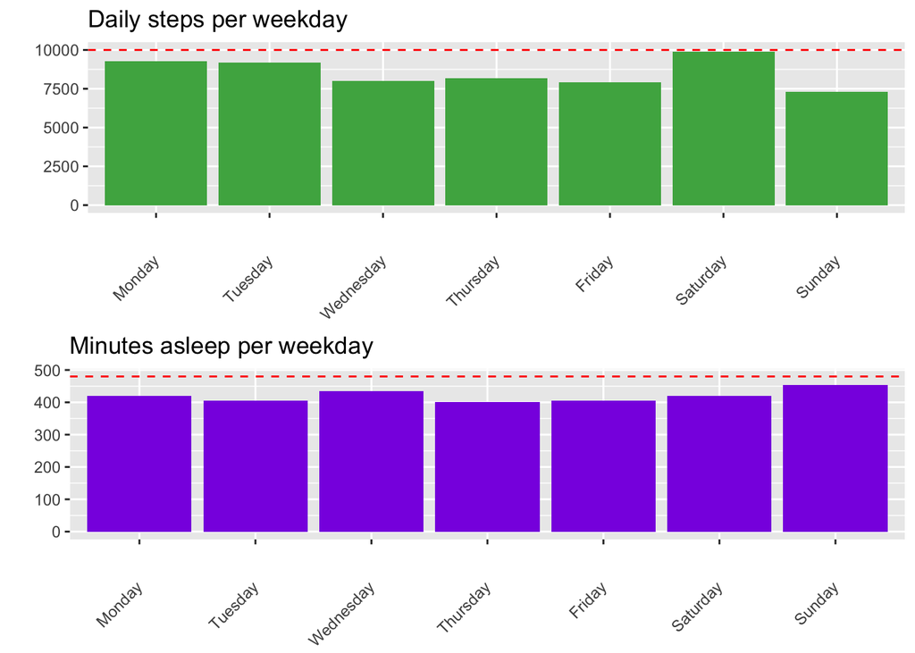

```r
library(ggpubr)

# Daily steps plot
p1 <- ggplot(weekday_steps_sleep) +
  geom_col(aes(weekday, daily_steps), fill = "#4CAF50") +
  geom_hline(yintercept = 10000, linetype="dashed", color="red") +
  labs(title = "Daily steps per weekday", x= "", y = "") +
  theme(axis.text.x = element_text(angle = 45, vjust = 0.5, hjust = 1))

# Daily sleep plot
p2 <- ggplot(weekday_steps_sleep, aes(weekday, daily_sleep)) +
  geom_col(fill = "#8A2BE2") +
  geom_hline(yintercept = 480, linetype="dashed", color="red") +
  labs(title = "Minutes asleep per weekday", x= "", y = "") +
  theme(axis.text.x = element_text(angle = 45, vjust = 0.5, hjust = 1))

# Arrange the plots
ggarrange(p1, p2, ncol = 1, nrow = 2)
```

##### Observations :

In the graphs above we can determine the following:

- Users generally do not reach the recommended 10,000 daily steps, though they come closest on Saturdays; Sundays show the lowest step counts.
- Users sleep less than the recommended 8 hours per night.

### Correlations

We will now investigate potential relationships between different variables in our dataset :

- Daily steps vs. daily sleep: Is there a link between the number of steps taken and the amount of sleep?
- Daily steps vs. calories burned: Does walking more relate to higher calorie expenditure?
- Very active users vs. distance covered: Do users classified as very active actually cover more distance?
- Calories vs. activity level: Is there a connection between calorie burn and whether users are active?

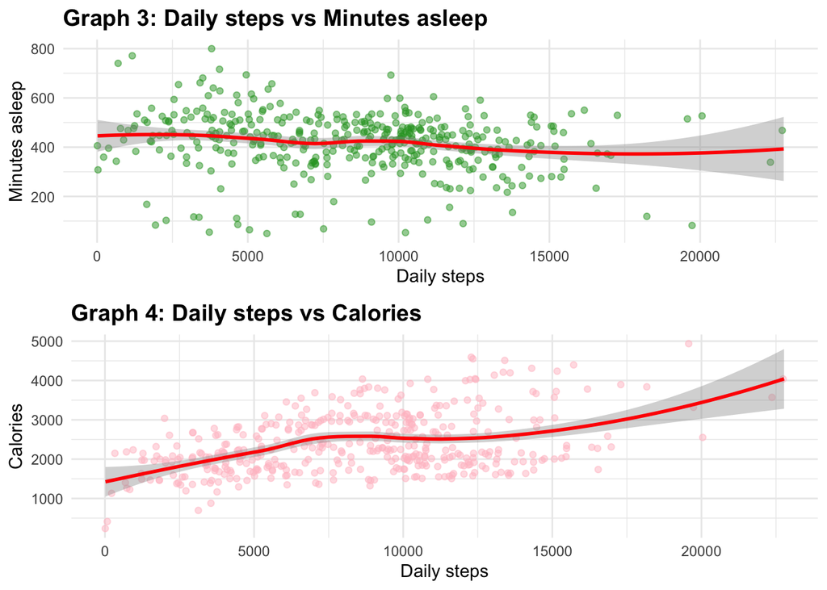

```r
p3 <- ggplot(daily_activity_sleep, aes(x = totalsteps, y = totalminutesasleep)) +
  geom_jitter(width = 50, height = 10, alpha = 0.5, color = "#2ca02c") +
  geom_smooth(color = "red") +
  labs(title = "Graph 3: Daily steps vs Minutes asleep", x = "Daily steps", y = "Minutes asleep") +
  theme_minimal() +
  theme(plot.title = element_text(size = 14, face = "bold"))

p4 <- ggplot(daily_activity_sleep, aes(x = totalsteps, y = calories)) +
  geom_jitter(width = 50, height = 50, alpha = 0.5, color = "pink") +
  geom_smooth(color = "red") +
  labs(title = "Graph 4: Daily steps vs Calories", x = "Daily steps", y = "Calories") +
  theme_minimal() +
  theme(plot.title = element_text(size = 14, face = "bold"))

ggarrange(p3, p4, ncol = 1, nrow = 2)
```

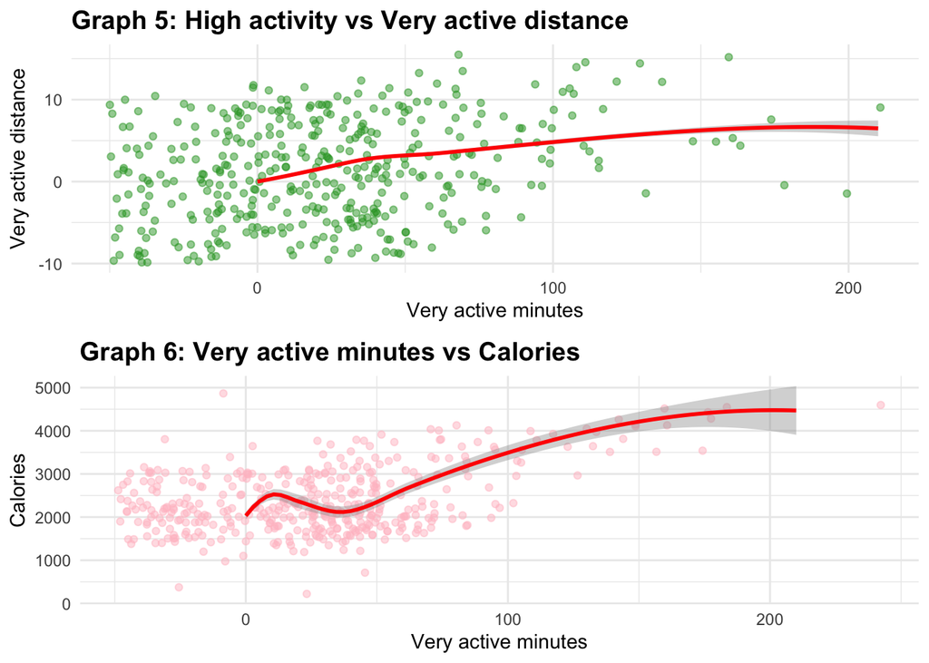

```r
p5 <- ggplot(daily_activity_sleep, aes(x = veryactiveminutes, y = veryactivedistance)) +
  geom_jitter(width = 50, height = 10, alpha = 0.5, color = "#2ca02c") +
  geom_smooth(color = "red") +
  labs(title = "Graph 5: High activity vs Very active distance", x = "Very active minutes", y = "Very active distance") +
  theme_minimal() +
  theme(plot.title = element_text(size = 14, face = "bold"))

p6 <- ggplot(daily_activity_sleep, aes(x = veryactiveminutes, y = calories)) +
  geom_jitter(width = 50, height = 50, alpha = 0.5, color = "pink") +
  geom_smooth(color = "red") +
  labs(title = "Graph 6: Very active minutes vs Calories", x = "Very active minutes", y = "Calories") +
  theme_minimal() +
  theme(plot.title = element_text(size = 14, face = "bold"))

ggarrange(p5, p6, ncol = 1, nrow = 2)
```

##### Observations

**Daily steps vs. daily sleep**: There appears to be a negative correlation between the number of steps taken and minutes of sleep per day. In other words, users who are more active tend to sleep slightly less.

**Daily steps vs. calories burned**: There is a positive correlation here: the more steps users take, the higher their calorie expenditure. This aligns with expectations.

**Very active users vs. distance covered**: Surprisingly, the data shows a positive correlation between very active minutes and distance covered. While the goal was to show that being “very active” is not always proportional to distance, the current dataset suggests otherwise. Graph (5) indicates some plateauing, which could be due to insufficient data, making it hard to confirm that very active users do not always travel long distances.

**Calories vs. activity level**: There is a positive trend: users with higher activity levels generally burn more calories, which matches the expected relationship.

Now that we’ve identified trends in activity, sleep, and calories burned, we want to examine how frequently users in our sample use their device. This will help us design a marketing strategy and determine which features could enhance smart device usage.

### Relationship with the devices

Let’s study loggedactivitiesdistance, which represents the distance a user manually logs in the app rather than what the device automatically detects. This can give us insight into how often they engage with their connected devices.

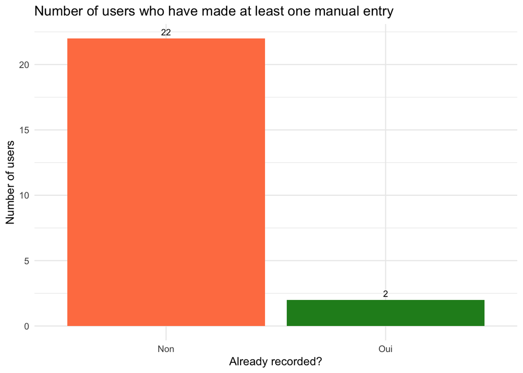

```r
library(ggplot2)
library(dplyr)

# Creation of a variable indicating whether a manual entry has already been made or not
user_manual_summary <- daily_activity_sleep %>%
  group_by(id) %>%
  summarise(has_logged = any(loggedactivitiesdistance > 0, na.rm = TRUE)) %>%
  ungroup() %>%
  # Counting the number of users by status
  count(has_logged)

ggplot(user_manual_summary, aes(x = has_logged, y = n, fill = has_logged)) +
  geom_col() +
  geom_text(aes(label = n), vjust = -0.5, size = 3) +
  scale_x_discrete(labels = c("Non", "Oui")) +
  labs(title = "Number of users who have made at least one manual entry",
       x = "Already recorded?", y = "Number of users") +
  theme_minimal() +
  scale_fill_manual(values = c("#FF7F50", "#228B22")) +
  theme(legend.position = "none")
```

##### Observations

We can see that very few people have manually entered their data on their connected device.

```r
# Number of days with manual activity per user
user_manual_days <- daily_activity_sleep %>%
  group_by(id) %>%
  summarise(days_logged = n()) %>%
  ungroup() %>%
  # Classification by usage level
  mutate(use_level = case_when(
    days_logged > 20 & days_logged <= 31 ~ "High use",
    days_logged >= 10 & days_logged <= 20 ~ "Moderate use",
    days_logged >= 1 & days_logged < 10 ~ "Low use",
    TRUE ~ "No use"
  ))

head(user_manual_days)
```

```
## # A tibble: 6 × 3
##           id days_logged use_level
##        <dbl>       <int> <chr>
## 1 1503960366          25 High use
## 2 1644430081           4 Low use
## 3 1844505072           3 Low use
## 4 1927972279           5 Low use
## 5 2026352035          28 High use
## 6 2320127002           1 Low use
```

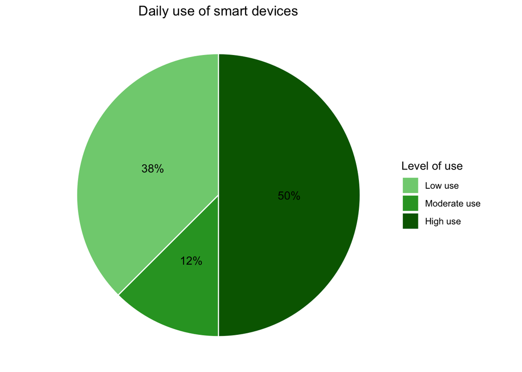

```r
# Counting users by usage level
user_manual_summary_level <- user_manual_days %>%
  group_by(use_level) %>%
  summarise(n = n()) %>%
  ungroup() %>%
  # Convert use_level to an ordered factor and calculate percentage
  mutate(use_level = factor(use_level, levels = c("No use", "Low use", "Moderate use", "High use")),
         percent = n / sum(n) * 100)

# Pie chart
ggplot(user_manual_summary_level, aes(x = "", y = percent, fill = use_level)) +
  geom_col(width = 1, color = "white") +
  coord_polar(theta = "y") +
  geom_text(aes(label = paste0(round(percent), "%")), position = position_stack(vjust = 0.5)) +
  scale_fill_manual(values = c("No use" = "#c7f0c7",  # very light green
                               "Low use" = "#7fcf7f",  # light green
                               "Moderate use" = "#2ca02c",  # medium green
                               "High use" = "#006400")) +  # dark green
  ggtitle("Daily use of smart devices") +
  labs(fill = "Level of use") +
  theme_void() +
  theme(legend.position = "right",
        plot.title = element_text(hjust = 0.5))
```

##### Observations

Finally,we’re going to study how much time do the users spend on their devices.

```r
daily_use_merged <- merge(daily_activity, user_manual_days, by=c ("id"))
head(daily_use_merged)
```

```
##           id       date totalsteps totaldistance trackerdistance
## 1 1503960366 2016-05-07      11992          7.71            7.71
## 2 1503960366 2016-05-06      12159          8.03            8.03
## 3 1503960366 2016-05-01      10602          6.81            6.81
## 4 1503960366 2016-04-30      14673          9.25            9.25
## 5 1503960366 2016-04-12      13162          8.50            8.50
## 6 1503960366 2016-04-13      10735          6.97            6.97
##   loggedactivitiesdistance veryactivedistance moderatelyactivedistance
## 1                        0               2.46                     2.12
## 2                        0               1.97                     0.25
## 3                        0               2.29                     1.60
## 4                        0               3.56                     1.42
## 5                        0               1.88                     0.55
## 6                        0               1.57                     0.69
##   lightactivedistance sedentaryactivedistance veryactiveminutes
```

[output cut: 20 more lines]

```r
n_distinct(daily_use_merged$id)
```

```
## [1] 24
```

```r
#24 OK.
```

We need to create a new data frame calculating the total amount of minutes users wore the device every day and creating three different categories: - All day - device was worn all day. - More than half day - device was worn more than half of the day. - Less than half day - device was worn less than half of the day.

```r
library(dplyr)
library(scales)

# 1. Calculate total minutes worn and categorize
minutes_worn <- daily_use_merged %>%
  mutate(
    total_minutes_worn = veryactiveminutes + fairlyactiveminutes + lightlyactiveminutes + sedentaryminutes,
    percent_minutes_worn = (total_minutes_worn / 1440) * 100,
    worn = case_when(
      percent_minutes_worn == 100 ~ "All day",
      percent_minutes_worn >= 50 & percent_minutes_worn < 100 ~ "More than half day",
      percent_minutes_worn > 0 & percent_minutes_worn < 50 ~ "Less than half day"
    )
  )

# 2. Overall percentage by category
minutes_worn_overall <- minutes_worn %>%
  group_by(worn) %>%
  summarise(total = n(), .groups = "drop") %>%
  mutate(
    total_percent = total / sum(total),
    labels = percent(total_percent)
  )

# 3. Percentage by usage level
minutes_worn_summary <- minutes_worn %>%
  group_by(use_level, worn) %>%
  summarise(total = n(), .groups = "drop") %>%
  group_by(use_level) %>%
  mutate(
    total_percent = total / sum(total),
    labels = percent(total_percent)
  ) %>%
  ungroup()

# 4. Ensure categories are in the correct order
levels_order <- c("All day", "More than half day", "Less than half day")
minutes_worn_overall$worn <- factor(minutes_worn_overall$worn, levels = levels_order)
minutes_worn_summary$worn <- factor(minutes_worn_summary$worn, levels = levels_order)

# 5. Check the results
head(minutes_worn_overall)
```

```
## # A tibble: 3 × 4
##   worn               total total_percent labels
##   <fct>              <int>         <dbl> <chr>
## 1 All day              260        0.365  36%
## 2 Less than half day    25        0.0351 4%
## 3 More than half day   428        0.600  60%
```

```r
head(minutes_worn_summary)
```

```
## # A tibble: 6 × 5
##   use_level worn               total total_percent labels
##   <chr>     <fct>              <int>         <dbl> <chr>
## 1 High use  All day               25        0.0676 6.8%
## 2 High use  Less than half day    16        0.0432 4.3%
## 3 High use  More than half day   329        0.889  88.9%
## 4 Low use   All day              215        0.802  80%
## 5 Low use   Less than half day     6        0.0224 2%
## 6 Low use   More than half day    47        0.175  18%
```

Now let’s vizualise this :

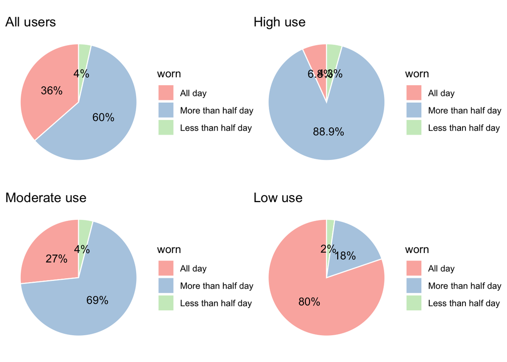

```r
library(dplyr)
library(tidyr)
library(scales)
library(ggplot2)
library(patchwork) # to arrange multiple pie charts

# Function to summarize totals and percentages for each use_level
summarize_worn <- function(df, use_level_filter = NULL) {
  data <- df
  if (!is.null(use_level_filter)) {
    data <- data %>% filter(use_level == use_level_filter)
  }

  data %>%
    group_by(worn) %>%
    summarise(total = n(), .groups = "drop") %>%
    mutate(
      totals = sum(total),
      total_percent = total / totals,
      labels = scales::percent(total_percent)
    ) %>%
    # ensure all categories are included
    complete(
      worn = c("All day", "More than half day", "Less than half day"),
      fill = list(total_percent = 0, labels = "0%")
    ) %>%
    mutate(worn = factor(worn, levels = c("All day", "More than half day", "Less than half day")))
}

# Apply function to overall and subsets
minutes_worn_percent <- summarize_worn(minutes_worn)
minutes_worn_highuse <- summarize_worn(minutes_worn, "High use")
minutes_worn_moduse <- summarize_worn(minutes_worn, "Moderate use")
minutes_worn_lowuse <- summarize_worn(minutes_worn, "Low use")

# Function to create a pie chart
plot_pie <- function(df, title) {
  ggplot(df, aes(x = "", y = total_percent, fill = worn)) +
    geom_col(color = "white") +
    geom_text(aes(label = labels), position = position_stack(vjust = 0.5)) +
    coord_polar(theta = "y") +
    theme_void() +
    labs(title = title) +
    scale_fill_brewer(palette = "Pastel1")
}

# Create and display the pie charts
p1 <- plot_pie(minutes_worn_percent, "All users")
p2 <- plot_pie(minutes_worn_highuse, "High use")
p3 <- plot_pie(minutes_worn_moduse, "Moderate use")
p4 <- plot_pie(minutes_worn_lowuse, "Low use")

# Arrange the four pie charts in a 2x2 grid
(p1 | p2) / (p3 | p4)
```

### Vizualisation

[Summary of visualizations created on Tableau can be found here](https://public.tableau.com/views/BellabeatDashboardGoogleCertificateCapsuleProject/Dashboard1?:language=fr-FR&:sid=&:redirect=auth&:display_count=n&:origin=viz_share_link)

## Conclusion

Based on an analysis of 24 users (a small sample), trends show that smart device usage focuses on activity, sleep, and wellness, they also show that activity levels vary widely between individuals, and engagement is limited, as only 2 out of 24 users manually logged their data. Most users rely on automatic tracking, highlighting the importance of seamless device integration.

Recommendations :

- Encourage consistent activity tracking (through notifications or daily step goals)
- Gamify distance milestones (rewards or challenges can boost motivation)
- Personalize insights (give feedback and suggestions based on each user’s activity patterns)
- Promote social sharing – allow users to share achievements to increase engagement and attract new users.